# Risk Factor Analysis

## Outcome Variable

**Outcome Variable:** wasted

## Predictor Variables

**Intervention Variable:** month

**Adjustment Set:**

unadjusted

## Stratifying Variables

The analysis was stratified on these variable(s):

- agecat
- studyid
- country

## Data Summary

| agecat | studyid | country | month | wasted | n_cell | n |
| --- | --- | --- | --- | --- | --- | --- |
| Birth | CMC-V-BCS-2002 | INDIA | 1 | 0 | 8 | 86 |
| Birth | CMC-V-BCS-2002 | INDIA | 1 | 1 | 1 | 86 |
| Birth | CMC-V-BCS-2002 | INDIA | 2 | 0 | 0 | 86 |
| Birth | CMC-V-BCS-2002 | INDIA | 2 | 1 | 1 | 86 |
| Birth | CMC-V-BCS-2002 | INDIA | 3 | 0 | 6 | 86 |
| Birth | CMC-V-BCS-2002 | INDIA | 3 | 1 | 1 | 86 |
| Birth | CMC-V-BCS-2002 | INDIA | 4 | 0 | 9 | 86 |
| Birth | CMC-V-BCS-2002 | INDIA | 4 | 1 | 0 | 86 |
| Birth | CMC-V-BCS-2002 | INDIA | 5 | 0 | 9 | 86 |
| Birth | CMC-V-BCS-2002 | INDIA | 5 | 1 | 0 | 86 |
| Birth | CMC-V-BCS-2002 | INDIA | 6 | 0 | 9 | 86 |
| Birth | CMC-V-BCS-2002 | INDIA | 6 | 1 | 1 | 86 |
| Birth | CMC-V-BCS-2002 | INDIA | 7 | 0 | 7 | 86 |
| Birth | CMC-V-BCS-2002 | INDIA | 7 | 1 | 0 | 86 |
| Birth | CMC-V-BCS-2002 | INDIA | 8 | 0 | 4 | 86 |
| Birth | CMC-V-BCS-2002 | INDIA | 8 | 1 | 0 | 86 |
| Birth | CMC-V-BCS-2002 | INDIA | 9 | 0 | 6 | 86 |
| Birth | CMC-V-BCS-2002 | INDIA | 9 | 1 | 2 | 86 |
| Birth | CMC-V-BCS-2002 | INDIA | 10 | 0 | 7 | 86 |
| Birth | CMC-V-BCS-2002 | INDIA | 10 | 1 | 1 | 86 |
| Birth | CMC-V-BCS-2002 | INDIA | 11 | 0 | 8 | 86 |
| Birth | CMC-V-BCS-2002 | INDIA | 11 | 1 | 3 | 86 |
| Birth | CMC-V-BCS-2002 | INDIA | 12 | 0 | 2 | 86 |
| Birth | CMC-V-BCS-2002 | INDIA | 12 | 1 | 1 | 86 |
| Birth | CMIN | BANGLADESH | 1 | 0 | 0 | 19 |
| Birth | CMIN | BANGLADESH | 1 | 1 | 0 | 19 |
| Birth | CMIN | BANGLADESH | 2 | 0 | 4 | 19 |
| Birth | CMIN | BANGLADESH | 2 | 1 | 0 | 19 |
| Birth | CMIN | BANGLADESH | 3 | 0 | 1 | 19 |
| Birth | CMIN | BANGLADESH | 3 | 1 | 1 | 19 |

[output cut: 1434 more lines]

The following strata were considered:

- agecat: 24 months, studyid: CMC-V-BCS-2002, country: INDIA
- agecat: 24 months, studyid: CMIN, country: BANGLADESH
- agecat: 24 months, studyid: CONTENT, country: PERU
- agecat: 24 months, studyid: EE, country: PAKISTAN
- agecat: 24 months, studyid: GMS-Nepal, country: NEPAL
- agecat: 24 months, studyid: IRC, country: INDIA
- agecat: 24 months, studyid: Keneba, country: GAMBIA
- agecat: 24 months, studyid: LCNI-5, country: MALAWI
- agecat: 24 months, studyid: MAL-ED, country: BANGLADESH
- agecat: 24 months, studyid: MAL-ED, country: BRAZIL
- agecat: 24 months, studyid: MAL-ED, country: INDIA
- agecat: 24 months, studyid: MAL-ED, country: NEPAL
- agecat: 24 months, studyid: MAL-ED, country: PERU
- agecat: 24 months, studyid: MAL-ED, country: SOUTH AFRICA
- agecat: 24 months, studyid: MAL-ED, country: TANZANIA, UNITED REPUBLIC OF
- agecat: 24 months, studyid: NIH-Birth, country: BANGLADESH
- agecat: 24 months, studyid: PROBIT, country: BELARUS
- agecat: 24 months, studyid: TanzaniaChild2, country: TANZANIA, UNITED REPUBLIC OF
- agecat: 24 months, studyid: ZVITAMBO, country: ZIMBABWE
- agecat: 6 months, studyid: CMC-V-BCS-2002, country: INDIA
- agecat: 6 months, studyid: CMIN, country: BANGLADESH
- agecat: 6 months, studyid: CONTENT, country: PERU
- agecat: 6 months, studyid: EE, country: PAKISTAN
- agecat: 6 months, studyid: GMS-Nepal, country: NEPAL
- agecat: 6 months, studyid: Guatemala BSC, country: GUATEMALA
- agecat: 6 months, studyid: IRC, country: INDIA
- agecat: 6 months, studyid: Keneba, country: GAMBIA
- agecat: 6 months, studyid: LCNI-5, country: MALAWI
- agecat: 6 months, studyid: MAL-ED, country: BANGLADESH
- agecat: 6 months, studyid: MAL-ED, country: BRAZIL
- agecat: 6 months, studyid: MAL-ED, country: INDIA
- agecat: 6 months, studyid: MAL-ED, country: NEPAL
- agecat: 6 months, studyid: MAL-ED, country: PERU
- agecat: 6 months, studyid: MAL-ED, country: SOUTH AFRICA
- agecat: 6 months, studyid: MAL-ED, country: TANZANIA, UNITED REPUBLIC OF
- agecat: 6 months, studyid: NIH-Birth, country: BANGLADESH
- agecat: 6 months, studyid: PROBIT, country: BELARUS
- agecat: 6 months, studyid: ResPak, country: PAKISTAN
- agecat: 6 months, studyid: SAS-CompFeed, country: INDIA
- agecat: 6 months, studyid: SAS-FoodSuppl, country: INDIA
- agecat: 6 months, studyid: TanzaniaChild2, country: TANZANIA, UNITED REPUBLIC OF
- agecat: 6 months, studyid: ZVITAMBO, country: ZIMBABWE
- agecat: Birth, studyid: CMC-V-BCS-2002, country: INDIA
- agecat: Birth, studyid: CMIN, country: BANGLADESH
- agecat: Birth, studyid: CONTENT, country: PERU
- agecat: Birth, studyid: EE, country: PAKISTAN
- agecat: Birth, studyid: GMS-Nepal, country: NEPAL
- agecat: Birth, studyid: IRC, country: INDIA
- agecat: Birth, studyid: Keneba, country: GAMBIA
- agecat: Birth, studyid: MAL-ED, country: BANGLADESH
- agecat: Birth, studyid: MAL-ED, country: BRAZIL
- agecat: Birth, studyid: MAL-ED, country: INDIA
- agecat: Birth, studyid: MAL-ED, country: NEPAL
- agecat: Birth, studyid: MAL-ED, country: PERU
- agecat: Birth, studyid: MAL-ED, country: SOUTH AFRICA
- agecat: Birth, studyid: MAL-ED, country: TANZANIA, UNITED REPUBLIC OF
- agecat: Birth, studyid: NIH-Birth, country: BANGLADESH
- agecat: Birth, studyid: PROBIT, country: BELARUS
- agecat: Birth, studyid: ResPak, country: PAKISTAN
- agecat: Birth, studyid: SAS-CompFeed, country: INDIA
- agecat: Birth, studyid: ZVITAMBO, country: ZIMBABWE

### Dropped Strata

Some strata were dropped due to rare outcomes:

- agecat: Birth, studyid: CMC-V-BCS-2002, country: INDIA
- agecat: Birth, studyid: CMIN, country: BANGLADESH
- agecat: Birth, studyid: CONTENT, country: PERU
- agecat: Birth, studyid: EE, country: PAKISTAN
- agecat: Birth, studyid: GMS-Nepal, country: NEPAL
- agecat: Birth, studyid: IRC, country: INDIA
- agecat: Birth, studyid: MAL-ED, country: BANGLADESH
- agecat: Birth, studyid: MAL-ED, country: BRAZIL
- agecat: Birth, studyid: MAL-ED, country: INDIA
- agecat: Birth, studyid: MAL-ED, country: NEPAL
- agecat: Birth, studyid: MAL-ED, country: PERU
- agecat: Birth, studyid: MAL-ED, country: SOUTH AFRICA
- agecat: Birth, studyid: MAL-ED, country: TANZANIA, UNITED REPUBLIC OF
- agecat: Birth, studyid: ResPak, country: PAKISTAN
- agecat: Birth, studyid: SAS-CompFeed, country: INDIA
- agecat: 6 months, studyid: CMC-V-BCS-2002, country: INDIA
- agecat: 6 months, studyid: CMIN, country: BANGLADESH
- agecat: 6 months, studyid: CONTENT, country: PERU
- agecat: 6 months, studyid: EE, country: PAKISTAN
- agecat: 6 months, studyid: GMS-Nepal, country: NEPAL
- agecat: 6 months, studyid: Guatemala BSC, country: GUATEMALA
- agecat: 6 months, studyid: IRC, country: INDIA
- agecat: 6 months, studyid: LCNI-5, country: MALAWI
- agecat: 6 months, studyid: MAL-ED, country: BANGLADESH
- agecat: 6 months, studyid: MAL-ED, country: BRAZIL
- agecat: 6 months, studyid: MAL-ED, country: INDIA
- agecat: 6 months, studyid: MAL-ED, country: NEPAL
- agecat: 6 months, studyid: MAL-ED, country: PERU
- agecat: 6 months, studyid: MAL-ED, country: SOUTH AFRICA
- agecat: 6 months, studyid: MAL-ED, country: TANZANIA, UNITED REPUBLIC OF
- agecat: 6 months, studyid: NIH-Birth, country: BANGLADESH
- agecat: 6 months, studyid: PROBIT, country: BELARUS
- agecat: 6 months, studyid: ResPak, country: PAKISTAN
- agecat: 6 months, studyid: SAS-FoodSuppl, country: INDIA
- agecat: 6 months, studyid: TanzaniaChild2, country: TANZANIA, UNITED REPUBLIC OF
- agecat: 24 months, studyid: CMC-V-BCS-2002, country: INDIA
- agecat: 24 months, studyid: CMIN, country: BANGLADESH
- agecat: 24 months, studyid: CONTENT, country: PERU
- agecat: 24 months, studyid: EE, country: PAKISTAN
- agecat: 24 months, studyid: GMS-Nepal, country: NEPAL
- agecat: 24 months, studyid: IRC, country: INDIA
- agecat: 24 months, studyid: LCNI-5, country: MALAWI
- agecat: 24 months, studyid: MAL-ED, country: BANGLADESH
- agecat: 24 months, studyid: MAL-ED, country: BRAZIL
- agecat: 24 months, studyid: MAL-ED, country: INDIA
- agecat: 24 months, studyid: MAL-ED, country: NEPAL
- agecat: 24 months, studyid: MAL-ED, country: PERU
- agecat: 24 months, studyid: MAL-ED, country: SOUTH AFRICA
- agecat: 24 months, studyid: MAL-ED, country: TANZANIA, UNITED REPUBLIC OF
- agecat: 24 months, studyid: NIH-Birth, country: BANGLADESH
- agecat: 24 months, studyid: PROBIT, country: BELARUS
- agecat: 24 months, studyid: TanzaniaChild2, country: TANZANIA, UNITED REPUBLIC OF
- agecat: 24 months, studyid: ZVITAMBO, country: ZIMBABWE

## Methods Detail

We’re interested in the causal parameters $E[Y_a]$ for all values of $a \in \mathcal{A}$. These parameters represent the mean outcome if, possibly contrary to fact, we intervened to set all units to have $A=a$. Under the randomization and positivity assumptions, these are identified by the statistical parameters $\psi_a=E_W[E_{Y|A,W}(Y|A=a,W)]$. In addition, we’re interested in the mean of $Y$, $E[Y]$ under no intervention (the observed mean). We will estimate these parameters by using SuperLearner to fit the relevant likelihood factors – $E_{Y|A,W}(Y|A=a,W)$ and $p(A=a|W)$, and then updating our likelihood fit using a joint TMLE.

For unadjusted analyses ($W=\{\}$), initial likelihoods were estimated using Lrnr_glm to estimate the simple $E(Y|A)$ and Lrnr_mean to estimate $p(A)$. For adjusted analyses, a small library containing Lrnr_glmnet, Lrnr_xgboost, and Lrnr_mean was used.

Having estimated these parameters, we will then use the delta method to estimate relative risks and attributable risks relative to a prespecified baseline level of $A$.

# Results Detail

## Results Plots

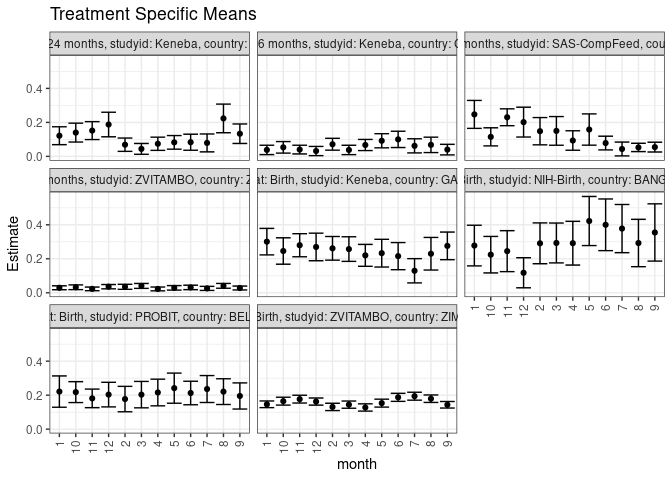

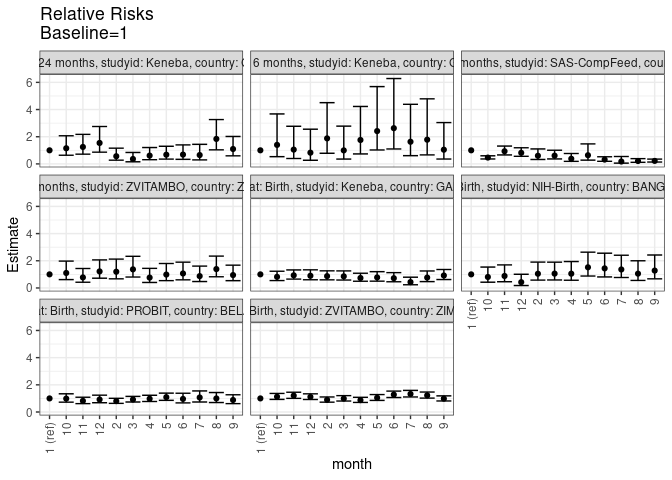

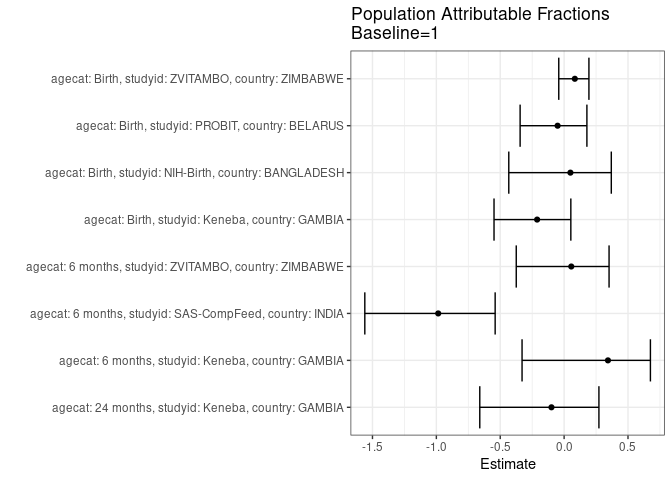

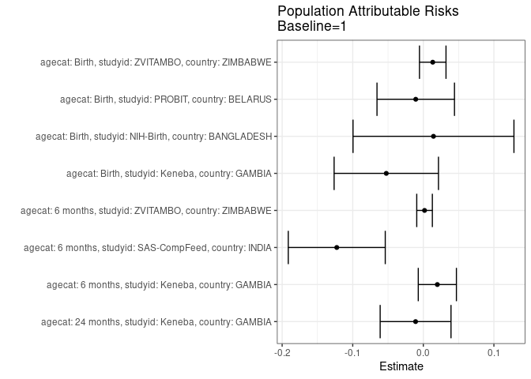

## Results Table

### Parameter: TSM

| agecat | studyid | country | intervention_level | baseline_level | estimate | ci_lower | ci_upper |
| --- | --- | --- | --- | --- | --- | --- | --- |
| Birth | Keneba | GAMBIA | 1 | NA | 0.3007519 | 0.2227886 | 0.3787152 |
| Birth | Keneba | GAMBIA | 2 | NA | 0.2614379 | 0.1917868 | 0.3310891 |
| Birth | Keneba | GAMBIA | 3 | NA | 0.2571429 | 0.1847206 | 0.3295651 |
| Birth | Keneba | GAMBIA | 4 | NA | 0.2201258 | 0.1557021 | 0.2845495 |
| Birth | Keneba | GAMBIA | 5 | NA | 0.2330097 | 0.1513403 | 0.3146792 |
| Birth | Keneba | GAMBIA | 6 | NA | 0.2156863 | 0.1358404 | 0.2955321 |
| Birth | Keneba | GAMBIA | 7 | NA | 0.1294118 | 0.0580312 | 0.2007923 |
| Birth | Keneba | GAMBIA | 8 | NA | 0.2297297 | 0.1338536 | 0.3256059 |
| Birth | Keneba | GAMBIA | 9 | NA | 0.2758621 | 0.1944996 | 0.3572245 |
| Birth | Keneba | GAMBIA | 10 | NA | 0.2457627 | 0.1680544 | 0.3234710 |
| Birth | Keneba | GAMBIA | 11 | NA | 0.2797619 | 0.2118613 | 0.3476626 |
| Birth | Keneba | GAMBIA | 12 | NA | 0.2695652 | 0.1884374 | 0.3506931 |
| Birth | NIH-Birth | BANGLADESH | 1 | NA | 0.2777778 | 0.1582102 | 0.3973453 |
| Birth | NIH-Birth | BANGLADESH | 2 | NA | 0.2909091 | 0.1707728 | 0.4110454 |
| Birth | NIH-Birth | BANGLADESH | 3 | NA | 0.2931034 | 0.1758568 | 0.4103501 |
| Birth | NIH-Birth | BANGLADESH | 4 | NA | 0.2916667 | 0.1629699 | 0.4203634 |
| Birth | NIH-Birth | BANGLADESH | 5 | NA | 0.4222222 | 0.2777878 | 0.5666567 |
| Birth | NIH-Birth | BANGLADESH | 6 | NA | 0.4000000 | 0.2480497 | 0.5519503 |
| Birth | NIH-Birth | BANGLADESH | 7 | NA | 0.3777778 | 0.2359991 | 0.5195564 |
| Birth | NIH-Birth | BANGLADESH | 8 | NA | 0.2926829 | 0.1532903 | 0.4320756 |
| Birth | NIH-Birth | BANGLADESH | 9 | NA | 0.3548387 | 0.1862631 | 0.5234144 |
| Birth | NIH-Birth | BANGLADESH | 10 | NA | 0.2241379 | 0.1167237 | 0.3315522 |
| Birth | NIH-Birth | BANGLADESH | 11 | NA | 0.2448980 | 0.1243879 | 0.3654081 |
| Birth | NIH-Birth | BANGLADESH | 12 | NA | 0.1176471 | 0.0291451 | 0.2061490 |
| Birth | PROBIT | BELARUS | 1 | NA | 0.2210526 | 0.1288901 | 0.3132151 |
| Birth | PROBIT | BELARUS | 2 | NA | 0.1770701 | 0.1024159 | 0.2517243 |
| Birth | PROBIT | BELARUS | 3 | NA | 0.2031250 | 0.1253653 | 0.2808847 |
| Birth | PROBIT | BELARUS | 4 | NA | 0.2157068 | 0.1371205 | 0.2942931 |
| Birth | PROBIT | BELARUS | 5 | NA | 0.2413066 | 0.1526197 | 0.3299936 |
| Birth | PROBIT | BELARUS | 6 | NA | 0.2127237 | 0.1434921 | 0.2819552 |

[output cut: 66 more lines]

### Parameter: E(Y)

| agecat | studyid | country | intervention_level | baseline_level | estimate | ci_lower | ci_upper |
| --- | --- | --- | --- | --- | --- | --- | --- |
| Birth | Keneba | GAMBIA | NA | NA | 0.2482947 | 0.2261720 | 0.2704173 |
| Birth | NIH-Birth | BANGLADESH | NA | NA | 0.2921739 | 0.2549711 | 0.3293768 |
| Birth | PROBIT | BELARUS | NA | NA | 0.2103206 | 0.1450833 | 0.2755580 |
| Birth | ZVITAMBO | ZIMBABWE | NA | NA | 0.1595572 | 0.1532418 | 0.1658725 |
| 6 months | Keneba | GAMBIA | NA | NA | 0.0579225 | 0.0479029 | 0.0679420 |
| 6 months | SAS-CompFeed | INDIA | NA | NA | 0.1244378 | 0.0992652 | 0.1496104 |
| 6 months | ZVITAMBO | ZIMBABWE | NA | NA | 0.0311581 | 0.0274654 | 0.0348509 |
| 24 months | Keneba | GAMBIA | NA | NA | 0.1106605 | 0.0958563 | 0.1254646 |

### Parameter: RR

| agecat | studyid | country | intervention_level | baseline_level | estimate | ci_lower | ci_upper |
| --- | --- | --- | --- | --- | --- | --- | --- |
| Birth | Keneba | GAMBIA | 1 | 1 | 1.0000000 | 1.0000000 | 1.0000000 |
| Birth | Keneba | GAMBIA | 2 | 1 | 0.8692810 | 0.5994098 | 1.2606559 |
| Birth | Keneba | GAMBIA | 3 | 1 | 0.8550000 | 0.5830776 | 1.2537354 |
| Birth | Keneba | GAMBIA | 4 | 1 | 0.7319182 | 0.4950724 | 1.0820726 |
| Birth | Keneba | GAMBIA | 5 | 1 | 0.7747573 | 0.5009994 | 1.1981030 |
| Birth | Keneba | GAMBIA | 6 | 1 | 0.7171569 | 0.4563965 | 1.1269016 |
| Birth | Keneba | GAMBIA | 7 | 1 | 0.4302941 | 0.2339279 | 0.7914961 |
| Birth | Keneba | GAMBIA | 8 | 1 | 0.7638514 | 0.4673481 | 1.2484674 |
| Birth | Keneba | GAMBIA | 9 | 1 | 0.9172414 | 0.6193700 | 1.3583670 |
| Birth | Keneba | GAMBIA | 10 | 1 | 0.8171610 | 0.5429209 | 1.2299252 |
| Birth | Keneba | GAMBIA | 11 | 1 | 0.9302083 | 0.6521624 | 1.3267977 |
| Birth | Keneba | GAMBIA | 12 | 1 | 0.8963043 | 0.6024900 | 1.3334022 |
| Birth | NIH-Birth | BANGLADESH | 1 | 1 | 1.0000000 | 1.0000000 | 1.0000000 |
| Birth | NIH-Birth | BANGLADESH | 2 | 1 | 1.0472727 | 0.5767647 | 1.9016075 |
| Birth | NIH-Birth | BANGLADESH | 3 | 1 | 1.0551724 | 0.5863054 | 1.8989914 |
| Birth | NIH-Birth | BANGLADESH | 4 | 1 | 1.0500000 | 0.5668647 | 1.9449085 |
| Birth | NIH-Birth | BANGLADESH | 5 | 1 | 1.5200000 | 0.8771223 | 2.6340683 |
| Birth | NIH-Birth | BANGLADESH | 6 | 1 | 1.4400000 | 0.8110273 | 2.5567574 |
| Birth | NIH-Birth | BANGLADESH | 7 | 1 | 1.3600000 | 0.7682869 | 2.4074341 |
| Birth | NIH-Birth | BANGLADESH | 8 | 1 | 1.0536585 | 0.5545023 | 2.0021491 |
| Birth | NIH-Birth | BANGLADESH | 9 | 1 | 1.2774194 | 0.6728487 | 2.4252113 |
| Birth | NIH-Birth | BANGLADESH | 10 | 1 | 0.8068966 | 0.4237030 | 1.5366472 |
| Birth | NIH-Birth | BANGLADESH | 11 | 1 | 0.8816327 | 0.4585166 | 1.6951973 |
| Birth | NIH-Birth | BANGLADESH | 12 | 1 | 0.4235294 | 0.1780231 | 1.0076063 |
| Birth | PROBIT | BELARUS | 1 | 1 | 1.0000000 | 1.0000000 | 1.0000000 |
| Birth | PROBIT | BELARUS | 2 | 1 | 0.8010312 | 0.6371256 | 1.0071028 |
| Birth | PROBIT | BELARUS | 3 | 1 | 0.9188988 | 0.7357174 | 1.1476894 |
| Birth | PROBIT | BELARUS | 4 | 1 | 0.9758165 | 0.7730242 | 1.2318086 |
| Birth | PROBIT | BELARUS | 5 | 1 | 1.0916253 | 0.8581947 | 1.3885494 |
| Birth | PROBIT | BELARUS | 6 | 1 | 0.9623213 | 0.6707253 | 1.3806879 |

[output cut: 66 more lines]

### Parameter: PAR

| agecat | studyid | country | intervention_level | baseline_level | estimate | ci_lower | ci_upper |
| --- | --- | --- | --- | --- | --- | --- | --- |
| Birth | Keneba | GAMBIA | 1 | NA | -0.0524572 | -0.1263815 | 0.0214671 |
| Birth | NIH-Birth | BANGLADESH | 1 | NA | 0.0143961 | -0.0996004 | 0.1283927 |
| Birth | PROBIT | BELARUS | 1 | NA | -0.0107320 | -0.0656188 | 0.0441547 |
| Birth | ZVITAMBO | ZIMBABWE | 1 | NA | 0.0133536 | -0.0054346 | 0.0321418 |
| 6 months | Keneba | GAMBIA | 1 | NA | 0.0198790 | -0.0071421 | 0.0469000 |
| 6 months | SAS-CompFeed | INDIA | 1 | NA | -0.1226210 | -0.1913269 | -0.0539152 |
| 6 months | ZVITAMBO | ZIMBABWE | 1 | NA | 0.0017464 | -0.0093103 | 0.0128031 |
| 24 months | Keneba | GAMBIA | 1 | NA | -0.0109611 | -0.0611390 | 0.0392167 |

### Parameter: PAF

| agecat | studyid | country | intervention_level | baseline_level | estimate | ci_lower | ci_upper |
| --- | --- | --- | --- | --- | --- | --- | --- |
| Birth | Keneba | GAMBIA | 1 | NA | -0.2112699 | -0.5486284 | 0.0525972 |
| Birth | NIH-Birth | BANGLADESH | 1 | NA | 0.0492725 | -0.4331122 | 0.3692868 |
| Birth | PROBIT | BELARUS | 1 | NA | -0.0510269 | -0.3443834 | 0.1783166 |
| Birth | ZVITAMBO | ZIMBABWE | 1 | NA | 0.0836917 | -0.0419267 | 0.1941652 |
| 6 months | Keneba | GAMBIA | 1 | NA | 0.3431998 | -0.3292104 | 0.6754566 |
| 6 months | SAS-CompFeed | INDIA | 1 | NA | -0.9854004 | -1.5599574 | -0.5397970 |
| 6 months | ZVITAMBO | ZIMBABWE | 1 | NA | 0.0560488 | -0.3746297 | 0.3517936 |
| 24 months | Keneba | GAMBIA | 1 | NA | -0.0990519 | -0.6601260 | 0.2723955 |